# Baseball

Daniel Kost-Stephenson

March 13, 2016

The goal of this exploration was to create preliminary visuals to examine batting performances over time. Different visuals were used to try and get the reader to understand how various statistics have changed over time (specifically power numbers in the “steroid era”). The groundwork has been set to create similar visuals using different statistics (e.g. density plots using SLG).

[interactive chart not shown]

The first plot is a series of boxplots showing the distribution of OPS from 1991 to 2014 and is intended to show the effect of steroids on player performance. By running the mouse over the various boxplots, we can easily observe that both the mean and 3rd quartiles are much higher from 1994-2006 than from 2006-2014. Steroids were popularized in 1991-1993 and MLB began regular testing for PEDs in 2003.

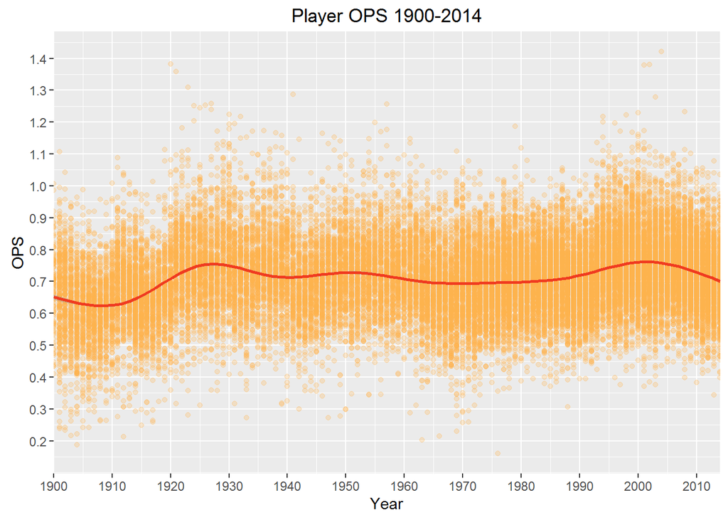

The second plot shows the layout of player OPS from 1900-2014 along with a fitted spline which indicates the general trend of OPS over time. The dead ball era and steroid era are very noticeable in this diagram.

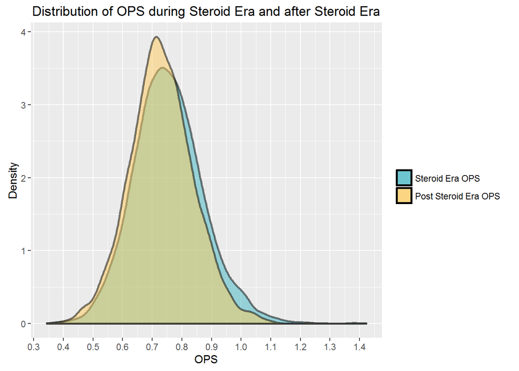

```
##                            Mean   Variance
## Steroid Era OPS      0.75522571 0.01401166
## Post Steroid Era OPS 0.73219804 0.01188740
```

[interactive chart not shown]

The above chart shows the decomposition of slugging percentage over time. The lack of power in the dead ball era is obvious: home runs and doubles were much less prevelant, but triples were more common. This could be because the parks in the dead ball era had abnormally large dimensions and so fielders could chase down balls that would have normally been home runs.

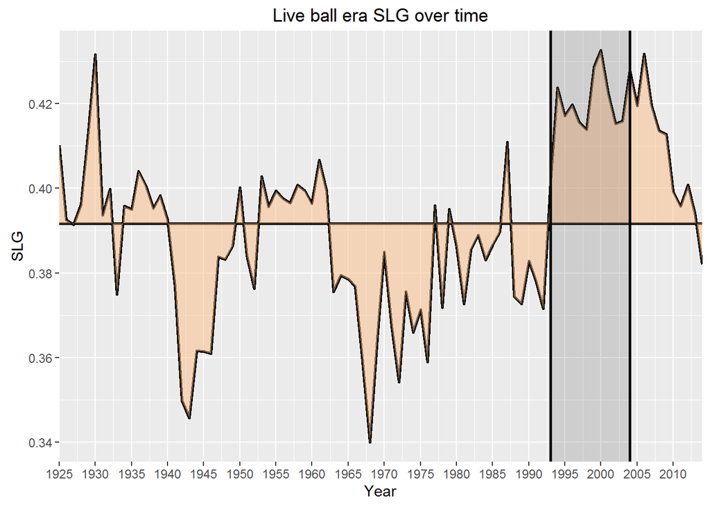

This chart simply shows how slugging percentage over time. The horizontal line represents the mean slugging percentage in the live ball era while the shaded region between the two vertical lines outlines the steroid era. The spike in slugging percentage is obvious, as is the decline after regular PED testing started.

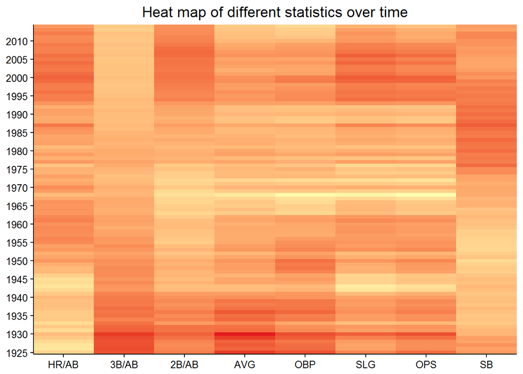

Above is a heat map displaying the trends of various common batting statistics over time. All statistics have been normalized so that the frequency of home runs, triples and doubles are calculated on a HR/AB, 3B/AB and 2B/AB basis.